# Using Data Mining Techniques into Real Estates Industry

**Author**: *Madalina-Alina Racovita, 1st year master's student on **Computational Optimization at Faculty of Computer Science**, UAIC, Iasi, Romania*

[figure not shown]

# Task 6 - Outliers Detection

## Import dependencies & environment configuration

```python
# !pip install
```

```python
import pandas as pd
import os
import matplotlib
import matplotlib.pyplot as plt
import warnings
import seaborn as sns
import numpy as np
from scipy.io import loadmat
from sklearn.metrics import classification_report
from collections import Counter

warnings.filterwarnings('ignore')
matplotlib.style.use('seaborn')

pd.set_option('display.max_columns', None)
pd.set_option('display.max_rows', None)
pd.set_option('display.expand_frame_repr', False)
pd.set_option('max_colwidth', -1)
```

## Load dataframes

```python
os.listdir('./Data')
```

```
['thyroid.mat', 'wine.mat']
```

### Labeled dataframe

The original **thyroid disease (ann-thyroid) dataset** from UCI machine learning repository is a classification dataset, which is suited for training ANNs. It has 3772 training instances and 3428 testing instances. It has 15 categorical and 6 real attributes. The problem is to determine whether a patient referred to the clinic is hypothyroid. Therefore three classes are built: normal (not hypothyroid), hyperfunction and subnormal functioning. For outlier detection, 3772 training instances are used, with only 6 real attributes. The hyperfunction class is treated as outlier class and other two classes are inliers, because hyperfunction is a clear minority class.

```python
data = loadmat('./Data/thyroid.mat')
len(data['X'][0])
```

```
6
```

```python
df_thyroid = pd.DataFrame()
for i in range(len(data['X'][0])):
    df_thyroid['Feature' + str(i)] = [data['X'][j][i] for j in range(len(data['X']))]
df_thyroid['Outlier'] = data['y']
df_thyroid['Outlier'] = df_thyroid['Outlier'].astype('int32')
df_thyroid.head()
```

|  | Feature0 | Feature1 | Feature2 | Feature3 | Feature4 | Feature5 | Outlier |
| --- | --- | --- | --- | --- | --- | --- | --- |
| 0 | 0.774194 | 0.001132 | 0.137571 | 0.275701 | 0.295775 | 0.236066 | 0 |
| 1 | 0.247312 | 0.000472 | 0.279886 | 0.329439 | 0.535211 | 0.173770 | 0 |
| 2 | 0.494624 | 0.003585 | 0.222960 | 0.233645 | 0.525822 | 0.124590 | 0 |
| 3 | 0.677419 | 0.001698 | 0.156546 | 0.175234 | 0.333333 | 0.136066 | 0 |
| 4 | 0.236559 | 0.000472 | 0.241935 | 0.320093 | 0.333333 | 0.247541 | 0 |

```python
df_thyroid['Outlier'].value_counts()
```

```
0    3679
1    93
Name: Outlier, dtype: int64
```

### Real estates dataframe

It is specified the fact that the features **UnitsInBuilding** and **Stories** are going to be removed from the dataframe, the outliers detection task is going to be pursued only of the real estates geographically localized in the a single county, I am going to choose **Washington state**, only for **RSFR** estates type.

```python
os.listdir('./../Data')
```

```
['RCON_12011.assessor.tsv',
 'RCON_53033.assessor.tsv',
 'RSFR_12011.assessor.tsv',
 'RSFR_53033.assessor.tsv']
```

```python
df = pd.concat([pd.read_csv("./../Data/RSFR_12011.assessor.tsv", sep = "\t"),
                     pd.read_csv("./../Data/RSFR_53033.assessor.tsv", sep = "\t")])

del df['UnitsInBuilding']
del df['Stories']

df = df[df['State'] == 'WA']

# removing constant features¶
columns_constant_features = ['AtticSqft', 'IsFixer', 'GarageNoOfCars', 'EffectiveYearBuilt', 'TotalRooms', 'State']
for current in columns_constant_features:
    del df[current]

# replacing the missing values
# removing columns with missing percentage ≥ 0.95

column_miss_perc_ge_95 = ['DeedType', 'RoofCode', 'BuildingShapeCode', 'City', 'StructureCode']
for column in column_miss_perc_ge_95:
    del df[column]

# replacing the missing values correspondingly to the feature type

features_with_missing_values = ['BuildingCode', 'GarageCarportCode', 'PatioPorchCode', 'PoolCode', 'Zonning', \
                                'PropTaxAmount', 'FoundationCode', 'ExteriorCode', 'CoolingCode', 'HeatingCode', \
                                'HeatingSourceCode', 'View', 'DocType', 'TransType', 'DistressCode', 'SellPrice']

object_miss_values_features = []
numeric_miss_values_features = []
types = df[features_with_missing_values].dtypes

for i in range(len(types)):
    if types[i] == object:
        object_miss_values_features.append(features_with_missing_values[i])
    else:
        numeric_miss_values_features.append(features_with_missing_values[i])

for column in object_miss_values_features:
    df[column] = df[column].fillna('')

rsfr_medium_sellprice = df['SellPrice'].mean()

for column in numeric_miss_values_features:
    if column != 'SellPrice':
        df[column] = df[column].fillna(0)

prices = []
for (index, row) in df.iterrows():
    added = False
    if pd.isnull(row['SellPrice']):
        row['SellPrice'] = row['LastSalePrice']
    if row['SellPrice'] == 0:
        prices.append(rsfr_medium_sellprice)
    elif row['SellPrice'] != 0:
        prices.append(row['SellPrice'])

df['SellPrice'] = prices

df.loc[df['LastSalePrice'] == 0, 'LastSalePrice'] = rsfr_medium_sellprice

# boolean type to numerical
bool_type_columns = df.select_dtypes(include=bool).columns.tolist()
for column in bool_type_columns:
    df[column] = df[column].apply(lambda x: 0 if x == False else 1)

# dropping corner cases observations
df = df.drop(df[df['SellPrice'] > 2500000].index)

# Constructing new features

df['SellDate_Year'] = df['SellDate'].apply(lambda x: int(x[:4]))
df['SellDate_Month'] = df['SellDate'].apply(lambda x: int(x[5:7]))
df['SellDate_Day'] = df['SellDate'].apply(lambda x: int(x[8:]))
del df['SellDate']

df['StatusDate'] = df['StatusDate'].apply(lambda x: str(x.split()[0]))

# features selection
# Pearson's correlation. selecting the most relevant continuous variables

corr = df.corr()
relevant_numerical_features = []
for key in corr['SellPrice'].keys():
    if abs(corr['SellPrice'][key]) > 0.08 and key != 'SellPrice':
        relevant_numerical_features.append(key)
relevant_numerical_features

print(str(len(corr['SellPrice']) - len(relevant_numerical_features)) + ' numerical features were removed due to small correlation from a ' \
+ 'total of ' + str(len(corr['SellPrice'])) + ' numerical features: ')

print(list(set(corr['SellPrice'].keys()).difference(set(relevant_numerical_features))))

# updating the simplified form that is going to be used in order to identify the outliers
df_houses = df[relevant_numerical_features]
df_houses['SellPrice'] = df['SellPrice']

print('\n FINISHED PREPROCESSING THE REAL ESTATES DATAFRAME \n\n')
df_houses.head()
```

```
20 numerical features were removed due to small correlation from a total of 41 numerical features:
['IsWaterfront', 'ConditionCode', 'DistrsdProp', 'SellDate_Month', 'Zip', 'OwnerOccupied', 'AssessedYear', 'CoolingCode', 'LastSalePrice', 'CountyFipsCode', 'LandSqft', 'ExteriorCode', 'BuildingCode', 'FoundationCode', 'ArmsLengthFlag', 'Longitude', 'StructureNbr', 'ConstructionCode', 'SellDate_Day'…

 FINISHED PREPROCESSING THE REAL ESTATES DATAFRAME
```

|  | LivingSqft | GarageSqft | BasementSqft | BasementFinishedSqft | Bedrooms | TotalBaths | FirePlaces | YearBuilt | QualityCode | HasPatioPorch | PatioPorchCode | HasPool | LandValue | ImprovementValue | TotalValue | PropTaxAmount | Latitude | HeatingSourceCode | View | ViewScore | SellDate_Year | SellPrice |
| --- | --- | --- | --- | --- | --- | --- | --- | --- | --- | --- | --- | --- | --- | --- | --- | --- | --- | --- | --- | --- | --- | --- |
| 0 | 950 | 260 | 1900 | 950 | 4 | 3.0 | 1 | 1954 | 6 | 0 | 0.0 | 0 | 292999 | 158999 | 452000 | 3959.0 | 47.568 | 3.0 | 0.0 | 1 | 2003 | 262890.0 |
| 1 | 2670 | 240 | 1580 | 1340 | 5 | 3.0 | 1 | 1954 | 8 | 1 | 2.0 | 0 | 232999 | 484999 | 718000 | 7196.0 | 47.508 | 2.0 | 3.0 | 3 | 2007 | 599999.0 |
| 2 | 2380 | 840 | 3720 | 1860 | 4 | 3.0 | 1 | 1972 | 8 | 0 | 0.0 | 0 | 677999 | 664999 | 1343000 | 11723.0 | 47.561 | 2.0 | 3.0 | 3 | 1986 | 250000.0 |
| 3 | 3300 | 820 | 0 | 0 | 4 | 4.0 | 1 | 1991 | 8 | 0 | 0.0 | 0 | 160999 | 319999 | 481000 | 6528.0 | 47.332 | 2.0 | 0.0 | 0 | 1991 | 235000.0 |
| 4 | 720 | 0 | 0 | 0 | 2 | 1.0 | 0 | 1950 | 4 | 0 | 0.0 | 0 | 263999 | 61999 | 326000 | 3346.0 | 47.575 | 2.0 | 0.0 | 1 | 2003 | 222000.0 |

```python
df_houses.shape
```

```
(52917, 22)
```

Since the task has a didactic purpose I am going to select among all 52K samples, the ones only from the year in which the sales number were maximal.

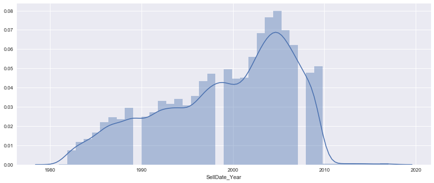

```python
fig = plt.figure(figsize=(15,6))
sns.distplot(df_houses['SellDate_Year'], bins=40)
plt.show()
```

```python
df_houses['SellDate_Year'].value_counts()[:5]
```

```
2005    3802
2004    3643
2006    3322
2003    3248
2007    2961
Name: SellDate_Year, dtype: int64
```

```python
df_houses = df_houses[df_houses['SellDate_Year']==2005]
```

## Univariate analysis: mean +/- k*sd, 1.5IQR rule

### On labeled dataframe

```python
features = list(df_thyroid)
features.remove('Outlier')

def see_data_distribution(df, column_name):
    fig = plt.figure(figsize=(20, 1))
    ax = sns.boxplot(x=df[column_name])
    plt.show()
```

```
__________________________________________1.5 IQR RULE___________________________________________
```

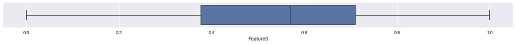

```
Feature0  -----------------  2.4655355249204667% from the samples were incorrectly detected

_______________ Detection Report _______________

               precision    recall  f1-score   support

           0       0.98      1.00      0.99      3679
           1       0.00      0.00      0.00        93

    accuracy                           0.98      3772
   macro avg       0.49      0.50      0.49      3772
weighted avg       0.95      0.98      0.96      3772

________________________________________________________________________________________________
```

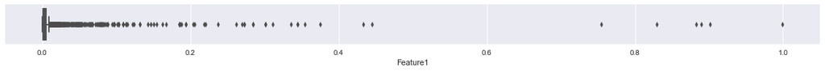

```
Feature1  -----------------  9.040296924708377% from the samples were incorrectly detected

_______________ Detection Report _______________

               precision    recall  f1-score   support

           0       1.00      0.91      0.95      3679
           1       0.21      1.00      0.35        93

    accuracy                           0.91      3772
   macro avg       0.61      0.95      0.65      3772
weighted avg       0.98      0.91      0.94      3772

________________________________________________________________________________________________
```

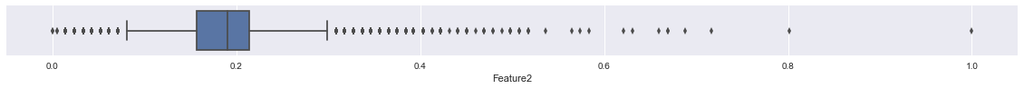

```
Feature2  -----------------  9.146341463414634% from the samples were incorrectly detected

_______________ Detection Report _______________

               precision    recall  f1-score   support

           0       0.99      0.92      0.95      3679
           1       0.13      0.48      0.21        93

    accuracy                           0.91      3772
   macro avg       0.56      0.70      0.58      3772
weighted avg       0.96      0.91      0.93      3772

________________________________________________________________________________________________
```

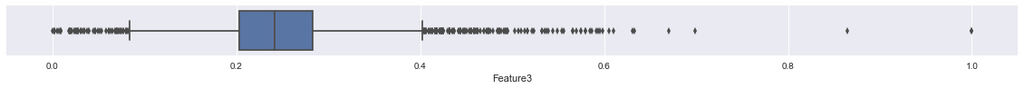

```
Feature3  -----------------  5.222693531283139% from the samples were incorrectly detected

_______________ Detection Report _______________

               precision    recall  f1-score   support

           0       0.99      0.96      0.97      3679
           1       0.26      0.59      0.36        93

    accuracy                           0.95      3772
   macro avg       0.62      0.77      0.67      3772
weighted avg       0.97      0.95      0.96      3772

________________________________________________________________________________________________
```

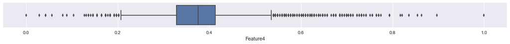

```
Feature4  -----------------  7.9798515376458115% from the samples were incorrectly detected

_______________ Detection Report _______________

               precision    recall  f1-score   support

           0       0.98      0.94      0.96      3679
           1       0.03      0.06      0.04        93

    accuracy                           0.92      3772
   macro avg       0.50      0.50      0.50      3772
weighted avg       0.95      0.92      0.94      3772

________________________________________________________________________________________________
```

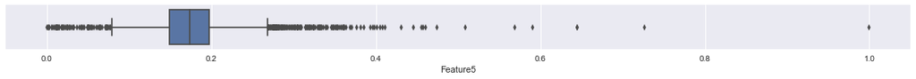

```
Feature5  -----------------  5.779427359490986% from the samples were incorrectly detected

_______________ Detection Report _______________

               precision    recall  f1-score   support

           0       0.99      0.95      0.97      3679
           1       0.26      0.71      0.38        93

    accuracy                           0.94      3772
   macro avg       0.62      0.83      0.67      3772
weighted avg       0.97      0.94      0.96      3772

________________________________________________________________________________________________


__________________________________________mean +/- k*sd ___________________________________________
```

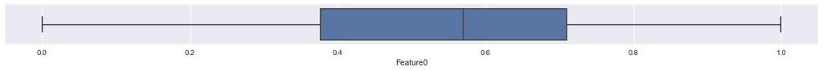

```
Feature0  -----------------  2.4655355249204667% from the samples were incorrectly detected

_______________ Detection Report _______________

               precision    recall  f1-score   support

           0       0.98      1.00      0.99      3679
           1       0.00      0.00      0.00        93

    accuracy                           0.98      3772
   macro avg       0.49      0.50      0.49      3772
weighted avg       0.95      0.98      0.96      3772

________________________________________________________________________________________________
```

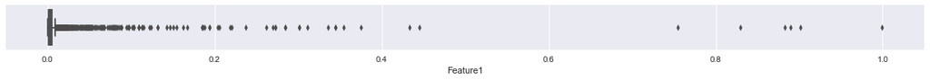

```
Feature1  -----------------  1.6967126193001063% from the samples were incorrectly detected

_______________ Detection Report _______________

               precision    recall  f1-score   support

           0       0.98      1.00      0.99      3679
           1       0.87      0.37      0.52        93

    accuracy                           0.98      3772
   macro avg       0.93      0.68      0.75      3772
weighted avg       0.98      0.98      0.98      3772

________________________________________________________________________________________________
```

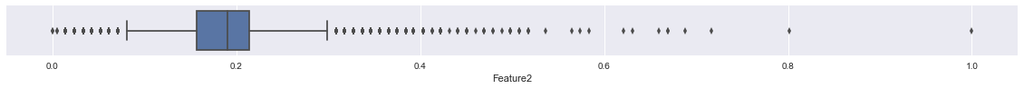

```
Feature2  -----------------  3.9501590668080593% from the samples were incorrectly detected

_______________ Detection Report _______________

               precision    recall  f1-score   support

           0       0.97      0.98      0.98      3679
           1       0.00      0.00      0.00        93

    accuracy                           0.96      3772
   macro avg       0.49      0.49      0.49      3772
weighted avg       0.95      0.96      0.96      3772

________________________________________________________________________________________________
```

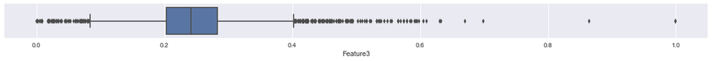

```
Feature3  -----------------  3.552492046659597% from the samples were incorrectly detected

_______________ Detection Report _______________

               precision    recall  f1-score   support

           0       0.98      0.99      0.98      3679
           1       0.11      0.06      0.08        93

    accuracy                           0.96      3772
   macro avg       0.54      0.53      0.53      3772
weighted avg       0.96      0.96      0.96      3772

________________________________________________________________________________________________
```

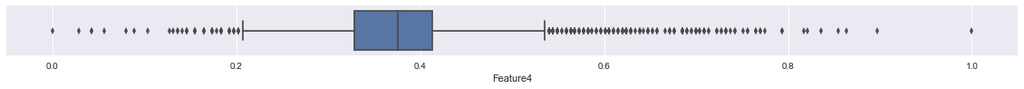

```
Feature4  -----------------  4.533404029692471% from the samples were incorrectly detected

_______________ Detection Report _______________

               precision    recall  f1-score   support

           0       0.97      0.98      0.98      3679
           1       0.00      0.00      0.00        93

    accuracy                           0.95      3772
   macro avg       0.49      0.49      0.49      3772
weighted avg       0.95      0.95      0.95      3772

________________________________________________________________________________________________
```

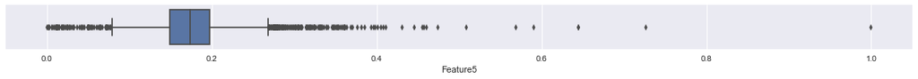

```
Feature5  -----------------  3.2873806998939554% from the samples were incorrectly detected

_______________ Detection Report _______________

               precision    recall  f1-score   support

           0       0.98      0.99      0.98      3679
           1       0.25      0.16      0.19        93

    accuracy                           0.97      3772
   macro avg       0.61      0.57      0.59      3772
weighted avg       0.96      0.97      0.96      3772

________________________________________________________________________________________________
```

```python
from statistics import stdev

def get_outliers_for_given_feature(df, feature):
    q1, q3 = np.percentile(df[feature], [25,75])
    iqr = q3 - q1
    lower_bound = q1 - (1.5 * iqr)
    upper_bound = q3 + (1.5 * iqr)
    return [(value < lower_bound) or (value > upper_bound) for value in list(df[feature])]

def outliers_mean_sd(df, feature):
    lower_bound = np.mean(df[feature]) - 3 * stdev(df[feature])
    upper_bound = np.mean(df[feature]) + 3 * stdev(df[feature])
    return [(value < lower_bound) or (value > upper_bound) for value in list(df[feature])]

def incorrecty_detected_percentage(pred_outliers):
    incorrect = 0
    true_outliers = list(df_thyroid['Outlier'])
    for i in range(len(true_outliers)):
        if true_outliers[i] != pred_outliers[i]:
            incorrect += 1
    return incorrect / len(true_outliers) * 100

def get_detection_results_on_labeled_df(feature, pred_outliers, visualization=True):
    if visualization:
        see_data_distribution(df_thyroid, column_name)

    print(feature + '  -----------------  ' + str(incorrecty_detected_percentage(pred_outliers)) +
          '% from the samples were incorrectly detected')

    print('\n_______________ Detection Report _______________\n\n',
          classification_report(list(df_thyroid['Outlier']), pred_outliers))
    print('________________________________________________________________________________________________\n\n')


print('__________________________________________1.5 IQR RULE___________________________________________')
for column_name in features:
    outliers_iqr = get_outliers_for_given_feature(df_thyroid, column_name)
    get_detection_results_on_labeled_df(column_name, outliers_iqr)


print('__________________________________________mean +/- k*sd ___________________________________________')
for column_name in features:
    outliers_iqr = outliers_mean_sd(df_thyroid, column_name)
    get_detection_results_on_labeled_df(column_name, outliers_iqr)
```

### On real estates dataframe

I am going to choose 5 numerical columns among all columns of the houses dataframe in order to identify the outliers samples.

```python
columns_for_outliers_detection = ['LivingSqft', 'TotalValue', 'Bedrooms', 'PropTaxAmount', 'SellPrice']
```

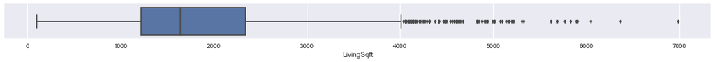

```
Accordingly to 1.5IQR rule 2.0515518148342977% are ourliers
```

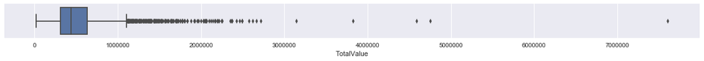

```
Accordingly to 1.5IQR rule 4.892162019989479% are ourliers
```

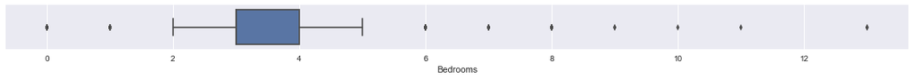

```
Accordingly to 1.5IQR rule 3.208837453971594% are ourliers
```

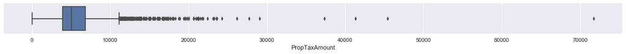

```
Accordingly to 1.5IQR rule 5.234087322461862% are ourliers
```

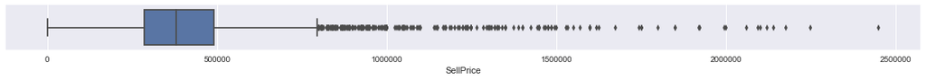

```
Accordingly to 1.5IQR rule 6.25986322987901% are ourliers
```

```python
for column_name in columns_for_outliers_detection:
    see_data_distribution(df_houses, column_name)

    outliers_iqr = get_outliers_for_given_feature(df_houses, column_name)
    print('Accordingly to 1.5IQR rule ' + str(sum(outliers_iqr) / len(list(df_houses[column_name]))* 100) + '% are ourliers')
    print('\n\n')
```

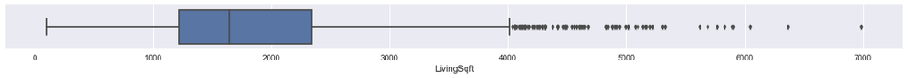

```
Accordingly to mean +/- k*sd rule 1.157285639137296% are ourliers
```

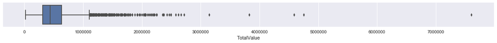

```
Accordingly to mean +/- k*sd rule 1.7622304050499737% are ourliers
```

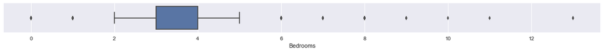

```
Accordingly to mean +/- k*sd rule 0.9994739610731194% are ourliers
```

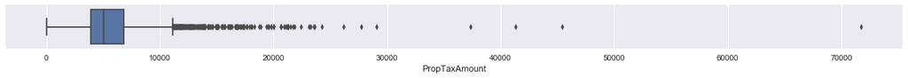

```
Accordingly to mean +/- k*sd rule 1.6833245660178853% are ourliers
```

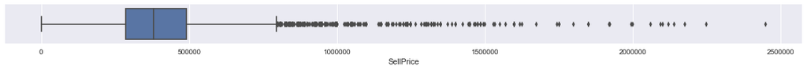

```
Accordingly to mean +/- k*sd rule 2.183061546554445% are ourliers
```

```python
for column_name in columns_for_outliers_detection:
    see_data_distribution(df_houses, column_name)

    outliers_iqr = outliers_mean_sd(df_houses, column_name)
    print('Accordingly to mean +/- k*sd rule ' + str(sum(outliers_iqr) / len(list(df_houses[column_name]))* 100) + '% are ourliers')
    print('\n\n')
```

## Multivariate analysis

### Outlier detection using Mahalanobis distance

#### On label dataframe

```python
from sklearn.decomposition import PCA
from sklearn.preprocessing import StandardScaler

def biplot(score, coeff, color_array, xlim, ylim, ids=[1, 2], labels=None):
    xs = score[:,0]
    ys = score[:,1]
    n = coeff.shape[0]

    scalex = 1.0/(xs.max() - xs.min())
    scaley = 1.0/(ys.max() - ys.min())

    fig = plt.figure(figsize=(12,12))
    maximum = max(color_array)

    plt.scatter(xs * scalex,ys * scaley, c = [plt.cm.jet(float(i)/maximum) for i in color_array],
                edgecolors='k', s=30)
    for i in range(n):
        plt.arrow(0, 0, coeff[i,0], coeff[i,1], color = 'r', alpha = 0.5)
        if labels is None:
            plt.text(coeff[i,0]* 1.15, coeff[i,1] * 1.15, "Var"+str(i+1), color = 'g', ha = 'center', va = 'center')
        else:
            plt.text(coeff[i,0]* 1.15, coeff[i,1] * 1.15, labels[i], color = 'g', ha = 'center', va = 'center')

    plt.title('Principal Components Analysis visualization')
    plt.xlim(*xlim)
    plt.ylim(*ylim)
    plt.xlabel("PrincipalComponent{}".format(ids[0]))
    plt.ylabel("PrincipalComponent{}".format(ids[1]))
    plt.grid()
    plt.show()
```

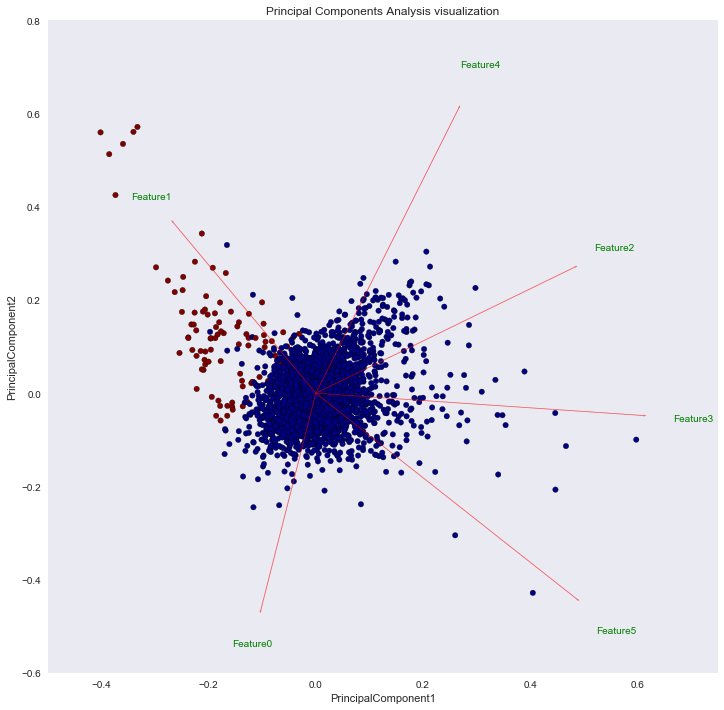

```python
pca = PCA()
pca_data = pca.fit_transform(StandardScaler().fit_transform(df_thyroid[features]))

biplot(pca_data[:, :2],
       np.transpose(pca.components_[:2, :]),
       df_thyroid['Outlier'], [-0.5, 0.75], [-0.6, .8], ids=[1, 2], labels=features)
```

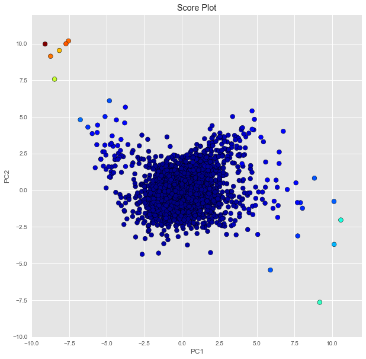

```python
# Compute the euclidean distance using the first 5 PC
euclidean = np.zeros(df_thyroid[features].shape[0])
for i in range(5):
    euclidean += (pca_data[:,i] - np.mean(pca_data[:,:5]))**2/np.var(pca_data[:,:5])

def see_outliers_based_on_distance(distances, pca_data, xlim, ylim):
    colors = [plt.cm.jet(float(i)/max(distances)) for i in distances]

    fig = plt.figure(figsize=(10,10))
    with plt.style.context(('ggplot')):
        plt.scatter(pca_data[:, 0], pca_data[:, 1], c=colors, edgecolors='k', s=60)
        plt.xlabel('PC1')
        plt.ylabel('PC2')
        plt.xlim(*xlim)
        plt.ylim(*ylim)
        plt.title('Score Plot')
    plt.show()

see_outliers_based_on_distance(euclidean, pca_data, [-10, 12], [-10, 12])
```

As it can be noticed, the **points towards the edges of along PC1 tends to have larger distances**. More or less as expected. In practice **Euclidean distance puts more weight than it should on correlated variables**.

The **major problem** with the approach above **is in the calculation of mean and standard deviation**. If we really had outliers in our data, they would definitely skew the calculation of mean and standard deviation.

**Mahalanobis distance** is very similar to the Euclidean distance, except each element of the summation is weighted by the corresponding element of the covariance matrix of the data. The details of the calculation are not really needed, as scikit-learn has a handy function to **calculate the Mahalanobis distance based on a robust estimation of the covariance matrix**.

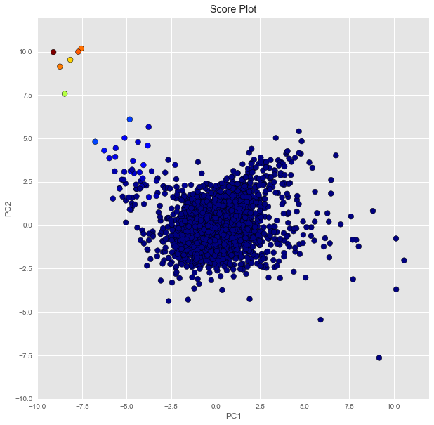

```python
from sklearn.covariance import EmpiricalCovariance, MinCovDet

# fit a Minimum Covariance Determinant (MCD) robust estimator to data
robust_cov = MinCovDet().fit(pca_data[:,:5])

# Get the Mahalanobis distance
mahalanobis_distances = robust_cov.mahalanobis(pca_data[:,:5])

see_outliers_based_on_distance(mahalanobis_distances, pca_data, [-10, 12], [-10, 12])
```

```python
def search_threshold_exhaustively(threshold_values, labeled_df=True):
    percentages = []
    outliers_no = []
    for value in threshold_values:
        pred_outliers = [distance < value for distance in mahalanobis_distances]
        if labeled_df:
            print(Counter(pred_outliers))
            get_detection_results_on_labeled_df('Mahalanobis distance detection', pred_outliers, False)
            percentages.append(incorrecty_detected_percentage(pred_outliers))
        else:
            outliers_no.append(sum(pred_outliers))
    return outliers_no

search_threshold_exhaustively([10, 5, 2, 0.6, 1e-1])
print('BEST THRESHOLD FOUND: ' + str(0.6))
```

```
Counter({True: 2664, False: 1108})
Mahalanobis distance detection  -----------------  73.09119830328738% from the samples were incorrectly detected

_______________ Detection Report _______________

               precision    recall  f1-score   support

           0       0.92      0.28      0.42      3679
           1       0.00      0.00      0.00        93

    accuracy                           0.27      3772
   macro avg       0.46      0.14      0.21      3772
weighted avg       0.89      0.27      0.41      3772

________________________________________________________________________________________________


Counter({False: 2020, True: 1752})
Mahalanobis distance detection  -----------------  48.91304347826087% from the samples were incorrectly detected

_______________ Detection Report _______________

               precision    recall  f1-score   support

           0       0.95      0.52      0.68      3679
           1       0.00      0.00      0.00        93

    accuracy                           0.51      3772
   macro avg       0.48      0.26      0.34      3772
weighted avg       0.93      0.51      0.66      3772

________________________________________________________________________________________________


Counter({False: 3216, True: 556})
Mahalanobis distance detection  -----------------  17.20572640509014% from the samples were incorrectly detected

_______________ Detection Report _______________

               precision    recall  f1-score   support
```

[output cut: 31 more lines]

```
_______________ Detection Report _______________

               precision    recall  f1-score   support

           0       0.98      1.00      0.99      3679
           1       0.00      0.00      0.00        93

    accuracy                           0.98      3772
   macro avg       0.49      0.50      0.49      3772
weighted avg       0.95      0.98      0.96      3772

________________________________________________________________________________________________


BEST THRESHOLD FOUND: 0.6
```

#### On real estates dataframe

```python
df_houses.shape
```

```
(3802, 22)
```

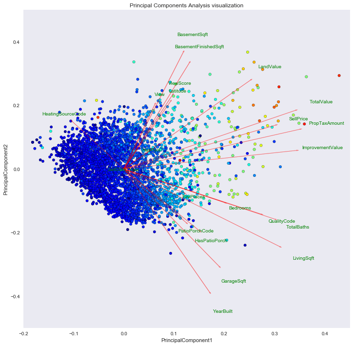

```python
pca = PCA()
pca_data = pca.fit_transform(StandardScaler().fit_transform(df_houses))

biplot(pca_data[:, :2],
       np.transpose(pca.components_[:2, :]),
       df_houses['SellPrice'], [-0.2, 0.45], [-0.5, 0.5], ids=[1, 2], labels=list(df_houses))
```

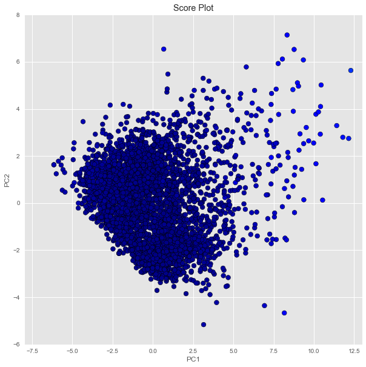

```python
euclidean = np.zeros(df_houses.shape[0])
for i in range(5):
    euclidean += (pca_data[:,i] - np.mean(pca_data[:,:5]))**2/np.var(pca_data[:,:5])

see_outliers_based_on_distance(euclidean, pca_data, [-8, 13], [-6, 8])
```

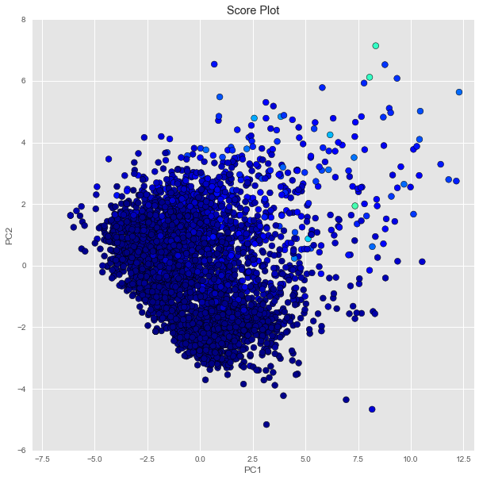

```python
robust_cov = MinCovDet().fit(pca_data[:,:5])
mahalanobis_distances = robust_cov.mahalanobis(pca_data[:,:5])

see_outliers_based_on_distance(mahalanobis_distances, pca_data, [-8, 13], [-6, 8])
```

```python
search_threshold_exhaustively([10, 5, 2, 1.1, 0.8, 1e-10], False)
```

```
[2292, 1579, 309, 56, 16, 0]
```

A good **threshold** accordingly to the visualisation for the outliers would be a value somewhere between **1.1** and **0.8**.

### Local outlier factor

The **Local Outlier Factor (LOF) algorithm** is an unsupervised anomaly detection method which computes the local density deviation of a given data point with respect to its neighbors. It considers as outliers the samples that have a substantially lower density than their neighbors.

#### On labeled dataframe

##### Outliers distribution visualization

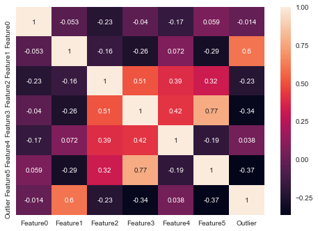

```python
corrMatrix = df_thyroid.corr()
sns.heatmap(corrMatrix, annot=True)
plt.show()
```

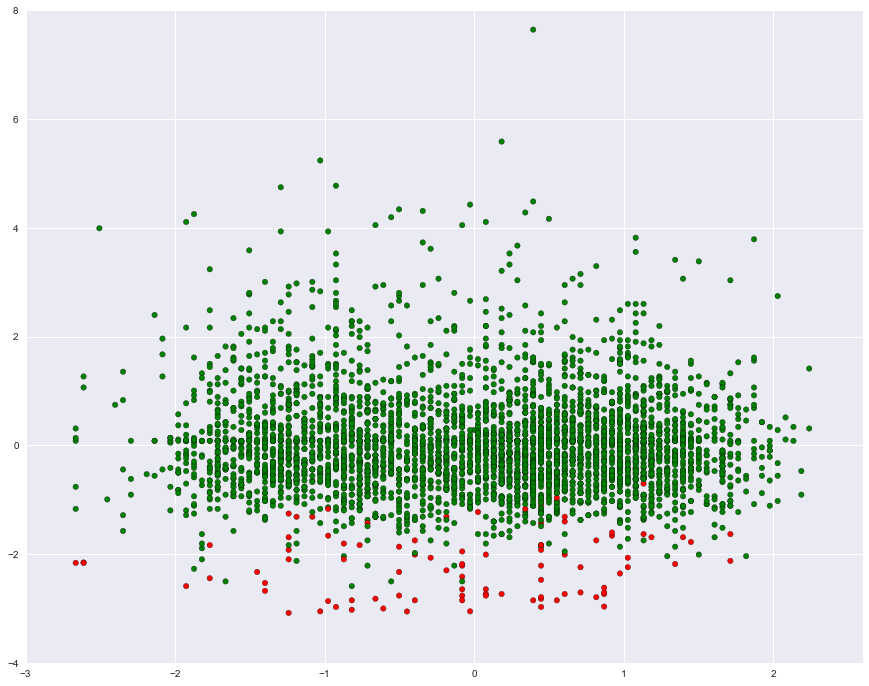

```python
def see_inner_outliers_distrib():
    scaled_x = StandardScaler().fit_transform(df_thyroid[features])
    scaled_x = pd.DataFrame(scaled_x, columns=features)

    fig = plt.figure(figsize=(15,12))
    plt.scatter(scaled_x['Feature0'], scaled_x['Feature3'], c=['red' if y == 1 else 'green' for y in df_thyroid['Outlier']],
                edgecolor='k', s=30)
    plt.xlim((-3, 2.6))
    plt.ylim((-4, 8))
    plt.show()

see_inner_outliers_distrib()
```

##### Building a LOF model using all of the features

I am going to **search exhaustively through a list of given parameters** to see the **best configuration** for LOF model.

```python
from sklearn.neighbors import LocalOutlierFactor

scaled_x = StandardScaler().fit_transform(df_thyroid[features])
scaled_x = pd.DataFrame(scaled_x, columns=features)


def build_lof_model(df, n_neighbors, contamination, features, labeled=True):
    scaled_x = StandardScaler().fit_transform(df[features])
    scaled_x = pd.DataFrame(scaled_x, columns=features)

    clf = LocalOutlierFactor(n_neighbors=n_neighbors, contamination=contamination)
    y_pred = clf.fit_predict(scaled_x[features])
    outliers_pred = [1 if y == -1 else 0 for y in y_pred]
    X_scores = clf.negative_outlier_factor_
    if labeled:
        return incorrecty_detected_percentage(outliers_pred), Counter(outliers_pred), X_scores, outliers_pred, clf
    else:
        return Counter(outliers_pred), X_scores, outliers_pred, clf

def pursue_exhausive_search_for_given_combination_of_features(df, features, labeled=True):
    config_results = dict()
    for n_neighbors in [1, 3, 4, 6, 10, 100]:
        for contamination in [0.03, 0.05, 0.1, 0.3]:
            config_results[(n_neighbors, contamination)] = build_lof_model(df, n_neighbors, contamination,features)[:2]
    if labeled:
        config_results = sorted(config_results.items(), key=lambda kv: kv[1])
    return config_results

config_results = pursue_exhausive_search_for_given_combination_of_features(df_thyroid, features)
config_results
```

```
[((100, 0.03), (3.3669141039236483, Counter({0: 3658, 1: 114}))),
 ((100, 0.05), (3.9766702014846236, Counter({0: 3583, 1: 189}))),
 ((10, 0.03), (5.16967126193001, Counter({0: 3658, 1: 114}))),
 ((1, 0.03), (5.275715800636267, Counter({0: 3658, 1: 114}))),
 ((3, 0.03), (5.487804878048781, Counter({0: 3658, 1: 114}))),
 ((4, 0.03), (5.487804878048781, Counter({0: 3658, 1: 114}))),
 ((6, 0.03), (5.487804878048781, Counter({0: 3658, 1: 114}))),
 ((10, 0.05), (6.892895015906681, Counter({0: 3583, 1: 189}))),
 ((1, 0.05), (7.0519618239660655, Counter({0: 3583, 1: 189}))),
 ((6, 0.05), (7.264050901378578, Counter({0: 3583, 1: 189}))),
 ((3, 0.05), (7.317073170731707, Counter({0: 3583, 1: 189}))),
 ((4, 0.05), (7.370095440084835, Counter({0: 3583, 1: 189}))),
 ((100, 0.1), (7.873806998939554, Counter({0: 3394, 1: 378}))),
 ((6, 0.1), (11.532343584305409, Counter({0: 3394, 1: 378}))),
 ((10, 0.1), (11.532343584305409, Counter({0: 3394, 1: 378}))),
 ((1, 0.1), (11.744432661717921, Counter({0: 3394, 1: 378}))),
 ((3, 0.1), (11.956521739130435, Counter({0: 3394, 1: 378}))),
 ((4, 0.1), (12.221633085896077, Counter({0: 3394, 1: 378}))),
 ((100, 0.3), (27.598091198303287, Counter({0: 2640, 1: 1132}))),
 ((10, 0.3), (30.30222693531283, Counter({0: 2640, 1: 1132}))),
 ((6, 0.3), (30.514316012725345, Counter({0: 2640, 1: 1132}))),
 ((3, 0.3), (30.620360551431602, Counter({0: 2640, 1: 1132}))),
 ((4, 0.3), (30.72640509013786, Counter({0: 2640, 1: 1132}))),
 ((1, 0.3), (30.832449628844117, Counter({0: 2640, 1: 1132})))]
```

Best configuration found: n_neighbors = 100 and contamination=0.03 with a prediction of 3658 inliners and 114 outliers with a percentage of 3.3669141039236483% incorrectly classified.

```python
_, _, X_scores, outliers_pred, clf = build_lof_model(df_thyroid, config_results[0][0][0],config_results[0][0][1], features)
get_detection_results_on_labeled_df('LOF', outliers_pred, False)
```

```
LOF  -----------------  3.3669141039236483% from the samples were incorrectly detected

_______________ Detection Report _______________

               precision    recall  f1-score   support

           0       0.99      0.98      0.98      3679
           1       0.35      0.43      0.39        93

    accuracy                           0.97      3772
   macro avg       0.67      0.70      0.68      3772
weighted avg       0.97      0.97      0.97      3772

________________________________________________________________________________________________
```

##### Building a LOF model using only 2 variables: 'Feature0' and 'Feature3'

```python
config_results = pursue_exhausive_search_for_given_combination_of_features(df_thyroid, ['Feature0', 'Feature3'])
config_results
```

```
[((100, 0.03), (2.99575821845175, Counter({0: 3658, 1: 114}))),
 ((100, 0.05), (3.870625662778367, Counter({0: 3583, 1: 189}))),
 ((10, 0.03), (5.143160127253447, Counter({0: 3659, 1: 113}))),
 ((6, 0.03), (5.328738069989396, Counter({0: 3658, 1: 114}))),
 ((4, 0.03), (5.434782608695652, Counter({0: 3658, 1: 114}))),
 ((1, 0.03), (5.461293743372217, Counter({0: 3659, 1: 113}))),
 ((3, 0.03), (5.461293743372217, Counter({1: 113, 0: 3659}))),
 ((10, 0.05), (6.945917285259809, Counter({0: 3583, 1: 189}))),
 ((1, 0.05), (7.131495227995758, Counter({0: 3596, 1: 176}))),
 ((4, 0.05), (7.158006362672323, Counter({0: 3583, 1: 189}))),
 ((6, 0.05), (7.211028632025451, Counter({0: 3583, 1: 189}))),
 ((3, 0.05), (7.423117709437964, Counter({1: 189, 0: 3583}))),
 ((100, 0.1), (8.29798515376458, Counter({0: 3394, 1: 378}))),
 ((10, 0.1), (11.426299045599151, Counter({0: 3394, 1: 378}))),
 ((6, 0.1), (11.691410392364793, Counter({0: 3394, 1: 378}))),
 ((4, 0.1), (11.876988335100743, Counter({0: 3393, 1: 379}))),
 ((3, 0.1), (12.11558854718982, Counter({1: 378, 0: 3394}))),
 ((1, 0.1), (12.486744432661718, Counter({0: 3394, 1: 378}))),
 ((100, 0.3), (27.75715800636267, Counter({0: 2640, 1: 1132}))),
 ((10, 0.3), (29.931071049840934, Counter({0: 2640, 1: 1132}))),
 ((1, 0.3), (30.03711558854719, Counter({0: 2654, 1: 1118}))),
 ((6, 0.3), (30.408271474019088, Counter({0: 2640, 1: 1132}))),
 ((3, 0.3), (30.514316012725345, Counter({1: 1132, 0: 2640}))),
 ((4, 0.3), (30.938494167550374, Counter({0: 2640, 1: 1132})))]
```

```python
_, _, X_scores, outliers_pred, clf = build_lof_model(df_thyroid, config_results[0][0][0],
                                                     config_results[0][0][1], ['Feature0', 'Feature3'])
get_detection_results_on_labeled_df('LOF', outliers_pred, False)
```

```
LOF  -----------------  2.99575821845175% from the samples were incorrectly detected

_______________ Detection Report _______________

               precision    recall  f1-score   support

           0       0.99      0.98      0.98      3679
           1       0.41      0.51      0.45        93

    accuracy                           0.97      3772
   macro avg       0.70      0.74      0.72      3772
weighted avg       0.97      0.97      0.97      3772

________________________________________________________________________________________________
```

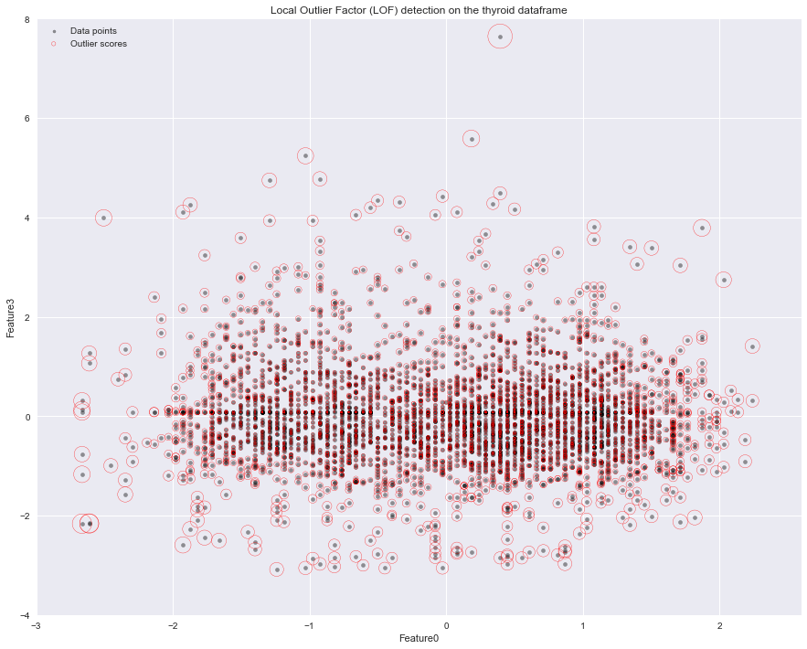

```python
fig = plt.figure(figsize=(15,12))

plt.title("Local Outlier Factor (LOF) detection on the thyroid dataframe")
plt.scatter(scaled_x['Feature0'], scaled_x['Feature3'], color='k', s=18, alpha=0.4, label='Data points')

# plot circles with radius proportional to the outlier scores
radius = (X_scores.max() - X_scores) / (X_scores.max() - X_scores.min())
plt.scatter(scaled_x['Feature0'], scaled_x['Feature3'], s=1000 * radius, edgecolors='r',
            facecolors='none', label='Outlier scores')

plt.axis('tight')
plt.xlim((-3, 2.6))
plt.ylim((-4, 8))
plt.xlabel('Feature0')
plt.ylabel('Feature3')

legend = plt.legend(loc='upper left')
legend.legendHandles[0]._sizes = [10]
legend.legendHandles[1]._sizes = [20]
plt.show()
```